# SAE Modélisation Statistique pour les données

# **I) Introduction**

Lors de cette SAE Modélisation statistique pour les données, nous allons nous intéresser à la classification de données textuelles. Nos données disposent de tweets écrits.  
Le dataset est disponible à l’adresse suivante:

https://www.kaggle.com/datasets/gargmanas/sentimental-analysis-for-tweets

Il s’agit d’un dataset contenant 10 314 observations et 3 variables:

-Index (ID du tweet)  
-message.to.examine (tweet)  
-label..depression.result (La personne est-elle en dépression? 0 pour non, 1 pour oui)

Le but est de fournir un outil capable de classer les tweets selon l’humeur de leur auteur. En particulier, on pourra tenter de repérer les tweets d’individus en dépression.

Nous allons pour cela utiliser différentes méthodes de classifications classique ou utilisées uniquement pour le Big Data, qui est ici notre problématique.

On va débuter par la préparation de nos données.

# **II) Préparation des données**

Ci-dessous, on retrouve l’ensemble des librairies qui vont être utilisées pour réaliser cette SAE.

```r
library(readr)
library(mvtnorm)
library(glmnet)
library(tm)
library(wordcloud2)
library(wordcloud)
```

On commence par importer notre fichier csv “sentiments_tweets” en enlevant la première colonne qui correspondait aux ID.

```r
data <- read.csv("sentiment_tweets3.csv", header = TRUE)
data=data[,-1]
```

On garde un échantillon de 1000 observations.

```r
set.seed(2024)
ech = sample(1:nrow(data),size = 1000)
data = data[ech,]
```

On va créer 2 dataframes, le premier n’ayant pas été écrit par une personne dépressive.  
Alors que le deuxième regroupera les tweets écrits par une personne en dépression.

```r
positif = subset(data,data$label..depression.result. =="0")
negatif= subset(data,data$label..depression.result. =="1")
```

Ici on va chercher les 100 premiers mots les plus fréquents dans les tweets négatifs mais aussi pour les positifs.

```r
all_reviews_negatif <- paste(negatif[,1], collapse = " ")
ctr = list(removePunctuation =T, stopwords = T)
freq_negatif = termFreq(all_reviews_negatif,control = ctr)


sorted_words_negatif <- sort(freq_negatif, decreasing = TRUE)

top_100_words_negatif <- head(sorted_words_negatif, 100)
mot_freq_negatif = names(top_100_words_negatif)


all_reviews_positif <- paste(positif[,1], collapse = " ")
ctr = list(removePunctuation =T, stopwords = T)
freq_positif = termFreq(all_reviews_positif,control = ctr)


sorted_words_positif <- sort(freq_positif, decreasing = TRUE)

top_100_words_positif <- head(sorted_words_positif, 100)
mot_freq_positif = names(top_100_words_positif)
```

Ci-dessous, nous retrouvons deux visualisations sous forme de nuage de mots :

- Le premier correspond aux mots que l’on retrouve le plus dans les tweets censés être positifs.

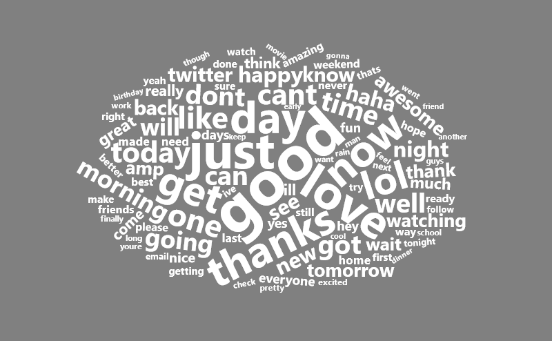

```r
#mots_positifs <- names(top_100_words_positif)

#data_positifs <- data.frame(word = mots_positifs, freq = top_100_words_positif)

#wordcloud2(data = data_positifs, size = 0.5, backgroundColor = "grey", color="white")
```

Les mots écrits les plus gros tels que “love” qui est affiché 52 fois, “thanks” qu’on retrouve 47 fois ou “good” dans plus de 60 tweets sont retrouvés le plus de fois dans les tweets positifs.

- Ensuite, nous avons le même nuage de mots avec les tweets négatifs.

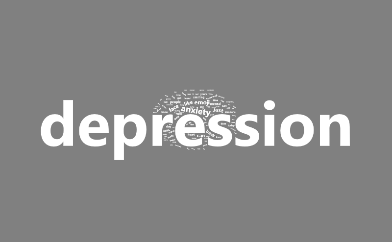

```r
#mots_negatifs <- names(top_100_words_negatif)

#data_negatif <- data.frame(word = mots_negatifs, freq = top_100_words_negatif)

#wordcloud2(data = data_negatif, size = 0.6, backgroundColor = "grey", color="white")
```

Ici, on peut voir que le mot “depression” apparaît 222 fois, il symbolise le plus les tweets négatifs, ce qui est une bonne nouvelle pour notre problématique, du fait que nous recherchons les tweets susceptibles d’avoir été écrit par une personne dépressive.

Nous allons à présent créer un vecteur sans les doublons des mots que l’on peut retrouver dans les deux groupes distincts comme “day” par exemple.

```r
mots_uniques <- intersect(mot_freq_positif, mot_freq_negatif)

mot_positif = setdiff(mot_freq_positif, mots_uniques)
mot_negatif = setdiff(mot_freq_negatif, mots_uniques)
```

On va créer la dataframe final sans les doublons que l’on va utiliser par la suite pour les méthodes de classification.

```r
df = data.frame(id = 1:1000, positive = "", negative = "")


i=0
for (i in 1:nrow(data)){
  texte=data$message.to.examine[i]
  texte <- as.character(texte)
  count_positive = rep(0,length(termFreq(texte)))
  count_negative = rep(0,length(termFreq(texte)))
  for (j in seq(1:length(termFreq(texte)))){
    if (names(termFreq(texte))[j] %in% mot_positif ){count_positive[j] = count_positive[j] + 1 }
    else if (names(termFreq(texte))[j] %in% mot_negatif){count_negative[j] = count_negative[j] + 1 }
  }
  df$positive[i] = sum(count_positive)
  df$negative[i] = sum(count_negative)

}
```

Nous allons créer de nouvelles colonnes : -une contenant le nombre de majuscules -une autre contenant le nombre de caractères -une dernière contenant le nombre de points d’exclamation.

Ces critères peuvent être associés aux sentiments retranscrits lorsque la personne écrit le tweet.

```r
## Compter le nombre de majuscule
compter_majuscules <- function(texte) {
  sum(utf8ToInt(texte) >= 65 & utf8ToInt(texte) <= 90)
}

df$nb_majuscule <- apply(data,1, compter_majuscules)


## Compter de nombre de caractère
data$nb_caracteres = 0
for (i in 1:nrow(data)) {
  texte[i] = data[i,1]

  df$nb_caracteres[i] = nchar(texte[i])

}


## Compter le nombre de points d'exclamation
compter_exclamation <- function(texte) {
  sum(utf8ToInt(texte) == 33)
}
df$nb_exclamation <- apply(data,1, compter_exclamation)
```

On change le nom de notre colonne “label” pour la renommer “avis”.  
Puis, on passe du format character à numérique pour les colonnes “positive” et “négative”.

```r
avis = data$label..depression.result.
df$avis <- ifelse(avis == "1", 1,  0)



df = df[,-1]
df <- df[complete.cases(df), ]
df=as.data.frame(df)
df$positive <- as.numeric(df$positive)
df$negative <- as.numeric(df$negative)
```

# **III) Méthodes de classification classique**

Afin d’utiliser les deux méthodes de classification classique, nous allons préparer un échantillon de 500 observations.  
On va par la suite le séparer en échantillon de train et de test (80% et 20%).

```r
set.seed(2024)
varbay=df[,1:6]
ach=sample(1:nrow(df),500,replace=F)
varbay= df[ach,]
```

#### **1. Classification naive bayésienne**

La classification naïve bayésienne est un modèle de classification qui suppose que les caractéristiques sont indépendantes entre elles. Malgré cette simplification, elle peut être très efficace pour classer les données. Elle utilise le théorème de Bayes pour calculer la probabilité qu’une observation appartienne à une classe donnée, en fonction de ses diverses caractéristiques.

On va lancer la boucle suivante qui va permettre de calculer la classification naïve bayésienne sur nos données sur 100 itérations.

```r
set.seed(2024)
res_bay=c()
verif_bay=c()
erreur_bay = rep(0,100)


library(emdbook)

for (i in 1:100) {

  train = sample(1:nrow(varbay),400,replace=F)
  varbay_train = varbay[train,]
  varbay_test = varbay[-train,]

  train_0 = varbay_train[varbay_train$avis==0,-6]
  train_1 = varbay_train[varbay_train$avis==1,-6]

  moy_0 = as.vector(apply(train_0,2,mean))
  moy_1 = as.vector(apply(train_1,2,mean))

  var_0 = var(train_0)
  var_1 = var(train_1)

  for (j in 1:nrow(varbay_test)) {

    test = as.matrix(varbay_test[j,-6])
    a=dmvnorm(test,mu=moy_0,Sigma=var_0) * (nrow(train_0)/500)
    b=dmvnorm(test,mu=moy_1,Sigma=var_1) * (nrow(train_1)/500)
    if (a>b) {
      res_bay[j]=0
    }
    else {
      res_bay[j]=1
    }
    if (res_bay[j]==varbay_test[j,6]) {
      verif_bay[j]="correct"
    }
    else {
      verif_bay[j]="incorrect"
      erreur_bay[i] = erreur_bay[i]+1
    }

  }

}
```

Dans cette boucle, on utilise un échantillon de train de 400 observations. Elles sont ensuite divisées en deux ensembles en fonction de la variable Avis. Les observations correspondant à Avis == 0 sont placées dans “train_0” et celles correspondant à Avis == 1 sont placées dans “train_1”. On calcule ensuite les moyennes et variances respectives.

Ensuite une autre boucle est créée afin de classer toutes les observations de l’échantillon de test. Pour chaque observation, les densités de probabilité sont calculées pour chaque classe à l’aide de la fonction dmvnorm en utilisant les moyennes et les variances calculées précédemment. Attention, il faut bien ajuster les probabilitées pour bien tenir compte de la taille du test.

Ensuite, une prédiction binaire (0 ou 1) est faite pour chaque observation de l’ensemble de test. La prédiction est comparée à la vraie valeur de la variable avis pour évaluer la précision de la prédiction.

Avec les résultats obtenus par cette boucle, on a calculé le taux d’erreur et le taux de réussite.

On calcule le taux d’erreur.

```r
set.seed(2024)
table(verif_bay)
```

```
verif_bay
  correct incorrect
       95         5
```

```r
mean(erreur_bay/100)
```

```
[1] 0.0758
```

On peut voir que sur 100 observations, 95 sont prédites correctement et seulement 5 ont une mauvaise prédiction.

```r
1-mean(erreur_bay/100)
```

```
[1] 0.9242
```

Enfin on retrouve un taux de réussite moyen de 92% pour la classification naïve bayésienne.

#### **2. Régression logistique**

La régression logistique est un outil statistique utilisé pour prédire des réponses binaires.

Elle fonctionne en prenant des données sur plusieurs variables et en les utilisant pour calculer la probabilité qu’un résultat soit correct ou incorrect.

Elle ajuste les données pour trouver les meilleurs coefficients qui minimisent l’erreur de prédiction. Ces coefficients indiquent l’importance de chaque variable dans la prédiction du résultat.

Enfin, une fois que le modèle est ajusté, il peut être utilisé pour prédire la probabilité qu’un nouvel ensemble de variables conduise à un résultat correct ou incorrect. Si cette probabilité est supérieure à 0.5 nous classons le résultat comme “correct”, sinon comme “incorrect”.

On va lancer la boucle qui permet de calculer la régression logistique sur nos données, toujours sur 100 itérations.

```r
set.seed(2024)
verif_reg=c()
erreur_reg=rep(0,100)


for (j in 1:100) {

  train = sample(1:nrow(varbay),400,replace=F)
  varbay_train = varbay[train,]
  varbay_test = varbay[-train,]

  reg_log = summary(glm(formula = varbay_train$avis ~ varbay_train$positive +varbay_train$negative + varbay_train$nb_majuscule +
                          varbay_train$nb_caracteres + varbay_train$nb_exclamation,
                        family = binomial(link = logit)))

  coef_reg_log = reg_log$coefficients


  for (i in 1:nrow(varbay_test)) {
    classe=c()
    ligne = varbay_test[i,-6]
    prob = 1/(1+exp(-coef_reg_log[1]-coef_reg_log[2]*varbay_test[i,1]-coef_reg_log[3]*varbay_test[i,2]-coef_reg_log[4]*varbay_test[i,3]-
                      coef_reg_log[5]*varbay_test[i,4]))
    if (prob>=1/2) {
      classe=append(classe,1)
    }
    else {
      classe=append(classe,0)
    }

    if (classe==(varbay_test[i,6])) {
      verif_reg=append(verif_reg,"correct")
    }
    else {
      verif_reg=append(verif_reg,"incorrect")
      erreur_reg[j]=erreur_reg[j]+1
    }

  }

}
```

À chaque itération, un ensemble de train est généré en sélectionnant aléatoirement 400 lignes à partir de l’ensemble de données varbay. Le reste des lignes forme l’ensemble de test.

On construit un modèle de régression logistique qui est ajusté aux données de train à l’aide de la fonction glm.

Pour chaque observation, le modèle est utilisé pour prédire la classe (0 ou 1) en fonction des caractéristiques de l’observation.  
Si la prédiction correspond à la vraie classe, le résultat est enregistré comme “correct”. Sinon, il est enregistré comme “incorrect”.

On va s’aider des résultats de la boucle pour calculer le taux d’erreur moyen et le taux de réussite moyen.

```r
table(verif_reg)
```

```
verif_reg
  correct incorrect
     9272       728
```

```r
mean(erreur_reg/100)
```

```
[1] 0.0728
```

Ici, sur nos différents tests effectués, nous avons 9272 observations prédites correctement et seulement 728 ayant une mauvaise prédiction.

On retrouve alors un taux d’erreur moyen de 7%

```r
1-mean(erreur_reg/100)
```

```
[1] 0.9272
```

Pour le taux de réussite moyen, celui-ci est de presque 93% pour la régression logistique sur nos données.

# **IV) Méthodes de classification en grande dimension**

Maintenant, nous allons voir les méthodes de classification pour la Big-Data, nous n’avons pas pu toutes les lancer à cause du serveur et du grand nombre de données que nous avons.

Nous allons d’abord commencer par préparer notre nouveau jeu de données qui est composé de beaucoup de variables qui correspond à tous les mots que l’on retrouve dans les tweets.  
Notre nouvelle table sera composée de 1000 observations avec 5037 variables.

#### **1. Préparation des données**

```r
set.seed(123)
corpus <- Corpus(VectorSource(data$message.to.examine))

dtm <- DocumentTermMatrix(corpus)

tfidf <- weightTfIdf(dtm)

tfidf_df <- as.data.frame(as.matrix(tfidf))
```

#### **2. Régression logistique LASSO**

Nous allons débuter avec la méthode de la Régression Logistique LASSO qui est une extension de la régression logistique standard qui intègre une régularisation de type LASSO. Le LASSO effectue à la fois une sélection de variables et une régularisation des coefficients. Son avantage principal est sa capacité à gérer les problèmes de surajustement en réduisant le nombre de variables dans le modèle.

```r
library(glmnet)
set.seed(123)
train_indices <- sample(1:nrow(tfidf_df), 0.8 * nrow(tfidf_df))

X_train <- as.matrix(tfidf_df[train_indices, ])
Y_train <- data$label..depression.result[train_indices]

X_test <- as.matrix(tfidf_df[-train_indices, ])
Y_test <- data$label..depression.result[-train_indices]

lasso_model <- cv.glmnet(X_train, Y_train, alpha = 1, family = "binomial")


predictions_lasso <- predict(lasso_model, newx = X_test, s = "lambda.min", type = "response")

accuracy_lassoT <- mean(ifelse(predictions_lasso > 0.5, 1, 0) == Y_test)
print(paste("Taux de réussite :", accuracy_lassoT))
```

```
[1] "Taux de réussite : 0.945"
```

On retrouve un taux de réussite avec la régression LASSO de 0.945.

```r
1-accuracy_lassoT
```

```
[1] 0.055
```

Et donc un taux d’erreur de seulement 5.5% pour la régression LASSO.

#### **3. Régression logistique RIDGE**

Ensuite, on poursuit avec la régression Ridge qui permet de construire un modèle qui prend en compte la relation entre les caractéristiques et la valeur prédite. Elle essaye d’éviter au mieux les problèmes de surajustement ou d’instabilité qui peuvent survenir lorsque les caractéristiques sont fortement corrélées.

```r
library(glmnet)

set.seed(123)
train_indices <- sample(1:nrow(tfidf_df), 0.8 * nrow(tfidf_df))

X_train <- as.matrix(tfidf_df[train_indices, ])
Y_train <- data$label..depression.result[train_indices]

X_test <- as.matrix(tfidf_df[-train_indices, ])
Y_test <- data$label..depression.result[-train_indices]

ridge_model <- cv.glmnet(X_train, Y_train, alpha = 0, family = "binomial")

predictions_ridge <- predict(ridge_model, newx = X_test, s = "lambda.min", type = "response")

accuracy_ridge <- mean(ifelse(predictions_ridge > 0.5, 1, 0) == Y_test)
print(paste("Taux de réussite :", accuracy_ridge))
```

```
[1] "Taux de réussite : 0.785"
```

Ici, nous avons un taux de réussite moyen de 0.785, ce qui est vraiment faible comparé aux résultats qu’on a trouvé avec la régression LASSO.

```r
1-accuracy_ridge
```

```
[1] 0.215
```

Et donc un taux d’erreur plutôt élevé avec 21.5%.

#### **4. Classification naïve bayésienne GLASSO**

La classification naïve bayésienne GLASSO est une variante de l’algorithme de classification naïve bayésienne qui utilise la régularisation LASSO pour estimer les paramètres du modèle. L’ajout de la régularisation LASSO dans la classification naïve bayésienne permet de réduire le surajustement en pénalisant les coefficients des caractéristiques qui sont moins importantes.

Pour cette méthode, on retrouve le code écrit mais nous n’avons pas pu l’exécuter à cause du serveur qui a eu plusieurs problèmes techniques.

Nous avons décidé de faire un échantillon plus petit afin de diminuer le temps d’exécution et la mémoire.

```r
#sample_indices <- sample(nrow(tfidf_df), 200 , replace = FALSE)
#sample_tfidf <- tfidf_df[sample_indices, ]
#sample_tfidf= as.data.frame(sample_tfidf)
```

```r
# library(glasso)
#
#
# set.seed(123)
# train_indices <- sample(1:nrow(sample_tfidf), 0.8 * nrow(sample_tfidf))
#
# X_train <- as.matrix(tfidf_df[train_indices, ])
# Y_train <- data$label..depression.result[train_indices]
#
# X_test <- as.matrix(tfidf_df[-train_indices, ])
# Y_test <- data$label..depression.result[-train_indices]
#
# precision_0 <- glasso(cov(X_train[Y_train == 0, ]), rho = 0.01)$wi
# precision_1 <- glasso(cov(X_train[Y_train == 1, ]), rho = 0.01)$wi
#
# predictions <- vector("numeric", length = nrow(X_test))
# for (i in 1:nrow(X_test)) {
#   prob_0 <- exp(-0.5 * t(X_test[i, ]) %*% solve(precision_0) %*% X_test[i, ]) / sqrt(det(precision_0))
#   prob_1 <- exp(-0.5 * t(X_test[i, ]) %*% solve(precision_1) %*% X_test[i, ]) / sqrt(det(precision_1))
#
#   if (prob_0 > prob_1) {
#     predictions[i] <- 0
#   } else {
#     predictions[i] <- 1
#   }
# }
#
#
# accuracy <- mean(predictions == Y_test)
# print(paste("Taux de réussite :", accuracy))
```

Nous n’avons pas eu le temps d’exécuter cette boucle par manque de temps et à cause des problèmes du serveur. Ce code a pour but d’effectuer une classification binaire en utilisant le Glasso pour prédire si les échantillons sont associés à la classe 0 ou 1.

Pour chaque classe (0 ou 1), le code estime la précision des données du train en utilisant une technique appelée Glasso. Cela signifie que le code essaie de comprendre les modèles de données de chaque classe.

Le code calcule les probabilités que chaque échantillon de test appartienne à chaque classe.

Une fois que toutes les prédictions sont faites, le code compare ces prédictions aux véritables étiquettes des échantillons dans l’ensemble de test. Puis il calcule la proportion qui est correctement prédit parmi tous les échantillons de test, on mesure la performance du modèle.

# **V) Comparaison des méthodes**

Nous avons analyser l’ensemble des méthodes classiques et de Big Data sur nos 2 jeux de données différents.

Nous allons comparer les taux d’erreur.

# **1.Tableaux taux de réussite**

On récupère ensuite tous les taux de réussite calculés précédemment. On divise par 100 car c’est le nombre d’observations que contient notre échantillon de test pour chaque itérations comme pour les taux d’erreur.

```r
g1=1-mean(erreur_bay/100)
g2=1-mean(erreur_reg/100)
g3=mean(accuracy_lassoT)
g4=mean(accuracy_ridge)
```

```r
resultatsR <- data.frame(Methode = c("Naïve Bayésienne", "Régression Logistique", "Régression Logistique LASSO",
                                    "Régression Logistique Ridge"),
                        Taux_Reussite = c(g1, g2,g3,g4))

print(resultatsR)
```

```
                      Methode Taux_Reussite
1            Naïve Bayésienne        0.9242
2       Régression Logistique        0.9272
3 Régression Logistique LASSO        0.9450
4 Régression Logistique Ridge        0.7850
```

Pour les méthodes de classification classique, les résultats obtenus sont quasiment pareils à 1% près. Alors que pour les méthodes de classification de Big Data, la régression logistique LASSO est largement au dessus avec un résultat d’environ 94.5% de celle du Ridge avec seulement 78.5%.

# **2.Tableaux taux d’erreur**

On récupère tous les taux d’erreur calculés précédemment. On divise par 100 lorsque cela est nécessaire, car c’est le nombre d’observations que contient notre échantillon de test pour chaque itération.

```r
f1=mean(erreur_bay/100)
f2=mean(erreur_reg/100)
f3=1-mean(accuracy_lassoT)
f4=1-mean(accuracy_ridge)
```

```r
resultatsE <- data.frame(Methode = c("Naïve Bayésienne", "Régression Logistique", "Régression Logistique LASSO",
                                    "Régression Logistique Ridge"),
                        Taux_Erreur = c(f1, f2,f3,f4))

print(resultatsE)
```

```
                      Methode Taux_Erreur
1            Naïve Bayésienne      0.0758
2       Régression Logistique      0.0728
3 Régression Logistique LASSO      0.0550
4 Régression Logistique Ridge      0.2150
```

Nous retrouvons exactement le même constat que pour les taux moyen de réussite. Au niveau des méthodes de classification classique, les deux disposent d’un taux d’erreur similaire. En revanche, pour les méthodes de classification en grande dimension, on remarque un grand écart entre les deux méthodes. La classification par la régression lasso reste la meilleure parmi les 4 avec 5.5% de taux d’erreur moyen.

# **Et le gagnant est..**

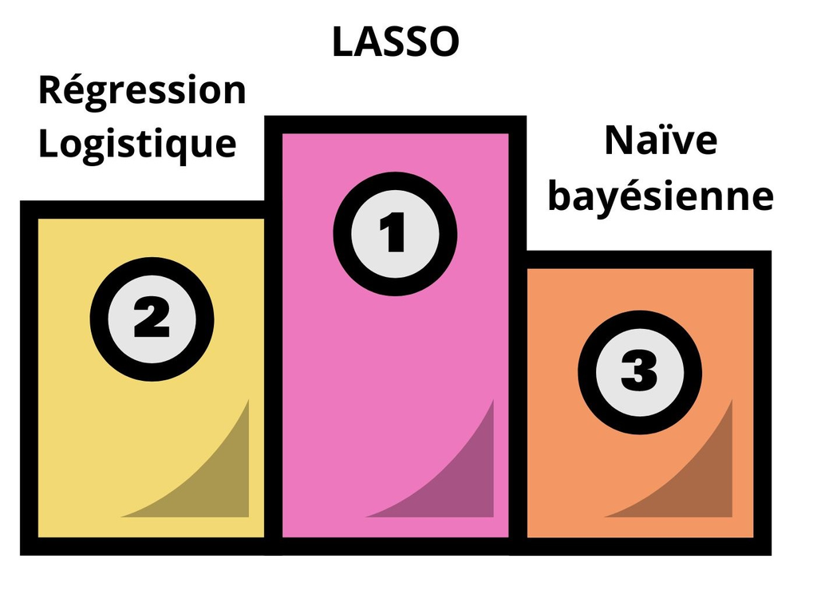

La méthode de classification de la régression LASSO dispose des meilleurs résultats sur notre jeu de données !